# Assignment-1

Anil Akyildirim, John K. Hancock, John Suh, Emmanuel

2/12/2020

## 0.1 Introduction

In this assignment, we are tasked to explore, analyze and model a major league baseball dataset which contains around 2000 records where each record presents a baseball team from 1871 to 2006. Each observation provides the perforamce of the team for that particular year with all the statistics for the performance of 162 game season. The problem statement for the main objective is that “Can we predict the number of wins for the team with the given attributes of each record?”. In order to provide a solution for the problem, our goal is to build a linear regression model on the training data that creates this prediction.

### 0.1.1 About the Data

The data set are provided in csv format as moneyball-evaluation-data and moneyball-training-data where we will explore, preperate and create our model with the training data and further test the model with the evaluation data. Below is short description of the variables within the datasets.

**INDEX: Identification Variable(Do not use)

**TARGET_WINS: Number of wins

**TEAM_BATTING_H : Base Hits by batters (1B,2B,3B,HR)

**TEAM_BATTING_2B: Doubles by batters (2B)

**TEAM_BATTING_3B: Triples by batters (3B)

**TEAM_BATTING_HR: Homeruns by batters (4B)

**TEAM_BATTING_BB: Walks by batters

**TEAM_BATTING_HBP: Batters hit by pitch (get a free base)

**TEAM_BATTING_SO: Strikeouts by batters

**TEAM_BASERUN_SB: Stolen bases

**TEAM_BASERUN_CS: Caught stealing

**TEAM_FIELDING_E: Errors

**TEAM_FIELDING_DP: Double Plays

**TEAM_PITCHING_BB: Walks allowed

**TEAM_PITCHING_H: Hits allowed

**TEAM_PITCHING_HR: Homeruns allowed

**TEAM_PITCHING_SO: Strikeouts by pitchers

## 0.2 Data Exploration

### 0.2.1 Descriptive Statistics

```r
# load libraries
library(ggplot2)
library(ggcorrplot)
library(psych)
library(statsr)
library(dplyr)
library("PerformanceAnalytics")
library(tidyr)
library(reshape2)
# Load data sets

baseball_eva <- read.csv("https://raw.githubusercontent.com/anilak1978/data621/master/moneyball-evaluation-data.csv")
baseball_train <- read.csv("https://raw.githubusercontent.com/anilak1978/data621/master/moneyball-training-data.csv")
```

We can start exploring our training data set by looking at basic descriptive statistics.

```r
# look at training dataset structure
str(baseball_train)
```

```
## 'data.frame':    2276 obs. of  17 variables:
##  $ INDEX           : int  1 2 3 4 5 6 7 8 11 12 ...
##  $ TARGET_WINS     : int  39 70 86 70 82 75 80 85 86 76 ...
##  $ TEAM_BATTING_H  : int  1445 1339 1377 1387 1297 1279 1244 1273 1391 1271 ...
##  $ TEAM_BATTING_2B : int  194 219 232 209 186 200 179 171 197 213 ...
##  $ TEAM_BATTING_3B : int  39 22 35 38 27 36 54 37 40 18 ...
##  $ TEAM_BATTING_HR : int  13 190 137 96 102 92 122 115 114 96 ...
##  $ TEAM_BATTING_BB : int  143 685 602 451 472 443 525 456 447 441 ...
##  $ TEAM_BATTING_SO : int  842 1075 917 922 920 973 1062 1027 922 827 ...
##  $ TEAM_BASERUN_SB : int  NA 37 46 43 49 107 80 40 69 72 ...
##  $ TEAM_BASERUN_CS : int  NA 28 27 30 39 59 54 36 27 34 ...
##  $ TEAM_BATTING_HBP: int  NA NA NA NA NA NA NA NA NA NA ...
##  $ TEAM_PITCHING_H : int  9364 1347 1377 1396 1297 1279 1244 1281 1391 1271 ...
##  $ TEAM_PITCHING_HR: int  84 191 137 97 102 92 122 116 114 96 ...
##  $ TEAM_PITCHING_BB: int  927 689 602 454 472 443 525 459 447 441 ...
##  $ TEAM_PITCHING_SO: int  5456 1082 917 928 920 973 1062 1033 922 827 ...
##  $ TEAM_FIELDING_E : int  1011 193 175 164 138 123 136 112 127 131 ...
##  $ TEAM_FIELDING_DP: int  NA 155 153 156 168 149 186 136 169 159 ...
```

We have 2276 observations and 17 variables. All of our variables are integer type as expected.

```r
# look at descriptive statistics
metastats <- data.frame(describe(baseball_train))
metastats <- tibble::rownames_to_column(metastats, "STATS")
metastats["pct_missing"] <- round(metastats["n"]/2276, 3)
head(metastats)
```

```
##             STATS vars    n       mean        sd median    trimmed
## 1           INDEX    1 2276 1268.46353 736.34904 1270.5 1268.56970
## 2     TARGET_WINS    2 2276   80.79086  15.75215   82.0   81.31229
## 3  TEAM_BATTING_H    3 2276 1469.26977 144.59120 1454.0 1459.04116
## 4 TEAM_BATTING_2B    4 2276  241.24692  46.80141  238.0  240.39627
## 5 TEAM_BATTING_3B    5 2276   55.25000  27.93856   47.0   52.17563
## 6 TEAM_BATTING_HR    6 2276   99.61204  60.54687  102.0   97.38529
##        mad min  max range         skew     kurtosis         se pct_missing
## 1 952.5705   1 2535  2534  0.004214942 -1.216756432 15.4346788           1
## 2  14.8260   0  146   146 -0.398723203  1.027475675  0.3301823           1
## 3 114.1602 891 2554  1663  1.571333477  7.278526076  3.0307891           1
## 4  47.4432  69  458   389  0.215101802  0.006160915  0.9810087           1
## 5  23.7216   0  223   223  1.109465188  1.503241779  0.5856226           1
## 6  78.5778   0  264   264  0.186042144 -0.963118866  1.2691285           1
```

```r
# Look for missing values
colSums(is.na(baseball_train))
```

```
##            INDEX      TARGET_WINS   TEAM_BATTING_H  TEAM_BATTING_2B
##                0                0                0                0
##  TEAM_BATTING_3B  TEAM_BATTING_HR  TEAM_BATTING_BB  TEAM_BATTING_SO
##                0                0                0              102
##  TEAM_BASERUN_SB  TEAM_BASERUN_CS TEAM_BATTING_HBP  TEAM_PITCHING_H
##              131              772             2085                0
## TEAM_PITCHING_HR TEAM_PITCHING_BB TEAM_PITCHING_SO  TEAM_FIELDING_E
##                0                0              102                0
## TEAM_FIELDING_DP
##              286
```

```r
# Percentage of missing values
missing_values <- metastats %>%
  filter(pct_missing < 1) %>%
  select(STATS, pct_missing) %>%
  arrange(pct_missing)

missing_values
```

```
##              STATS pct_missing
## 1 TEAM_BATTING_HBP       0.084
## 2  TEAM_BASERUN_CS       0.661
## 3 TEAM_FIELDING_DP       0.874
## 4  TEAM_BASERUN_SB       0.942
## 5  TEAM_BATTING_SO       0.955
## 6 TEAM_PITCHING_SO       0.955
```

When we look at the missing values within the training data set, we see that proportionaly against the total observations, TEAM_BATTING_HBP and TEAM_BESARUN_CS variables have the most missing values. We will be handling these missing values in our Data Preperation section.

### 0.2.2 Correlation and Distribution

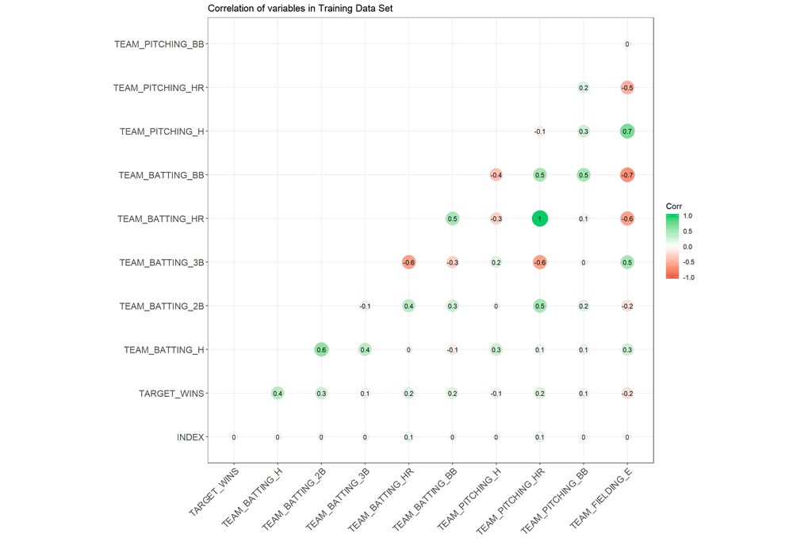

```r
# Look at correlation between variables

corr <- round(cor(baseball_train), 1)

ggcorrplot(corr,
           type="lower",
           lab=TRUE,
           lab_size=3,
           method="circle",
           colors=c("tomato2", "white", "springgreen3"),
           title="Correlation of variables in Training Data Set",
           ggtheme=theme_bw)
```

Team_Batting_H and Team_Batting_2B have the strongest positive correlation with Target_Wins. We also see that, there is a strong correlation between Team_Batting_H and Team_Batting_2B, Team_Pitching_B and TEAM_FIELDING_E. We will consider these findings on model creation as collinearity might complicate model estimation and we want to have explanotry variables to be independent from each other. We will try to avoid adding explanotry variables that are correlated to each other.

Let’s look at the correlations and distribution of the variables in more detail.

```r
# Look at correlation from batting, baserunning, pitching and fielding perspective
Batting_df <- baseball_train[c(2:7, 10)]
BaseRunning_df <- baseball_train[c(8:9)]
Pitching_df <- baseball_train[c(11:14)]
Fielding_df <- baseball_train[c(15:16)]
```

#### 0.2.2.1 Batting

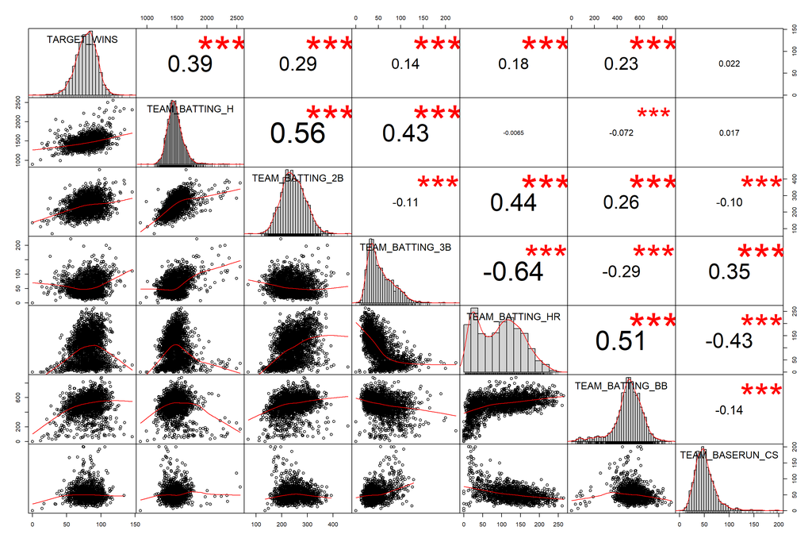

```r
# Batting Correlations
chart.Correlation(Batting_df, histogram=TRUE, pch=19)
```

#### 0.2.2.2 Baserunning

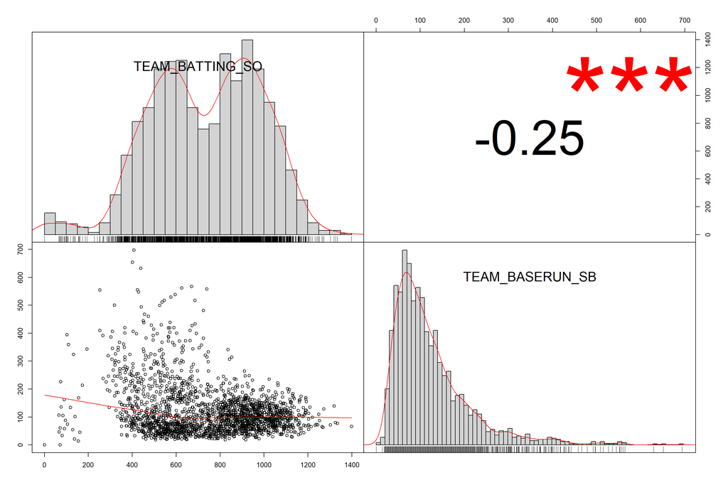

```r
# baserunning Correlation

chart.Correlation(BaseRunning_df, histogram=TRUE, pch=19)
```

TEAM_BASERUN_SB is right skewed and TEAM_BATTING_SO is bimodal.

#### 0.2.2.3 Pitching

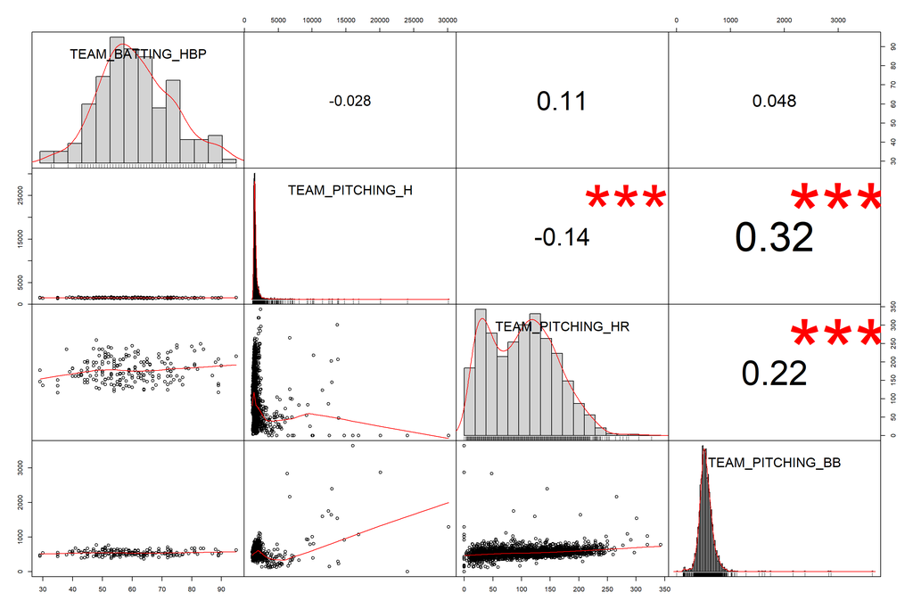

```r
#pitching correlations
chart.Correlation(Pitching_df, histogram=TRUE, pch=19)
```

TEAM_BATTING_HBP seems to be normally distributed however we shouldnt forget that we have a lot of missing values in this variable.

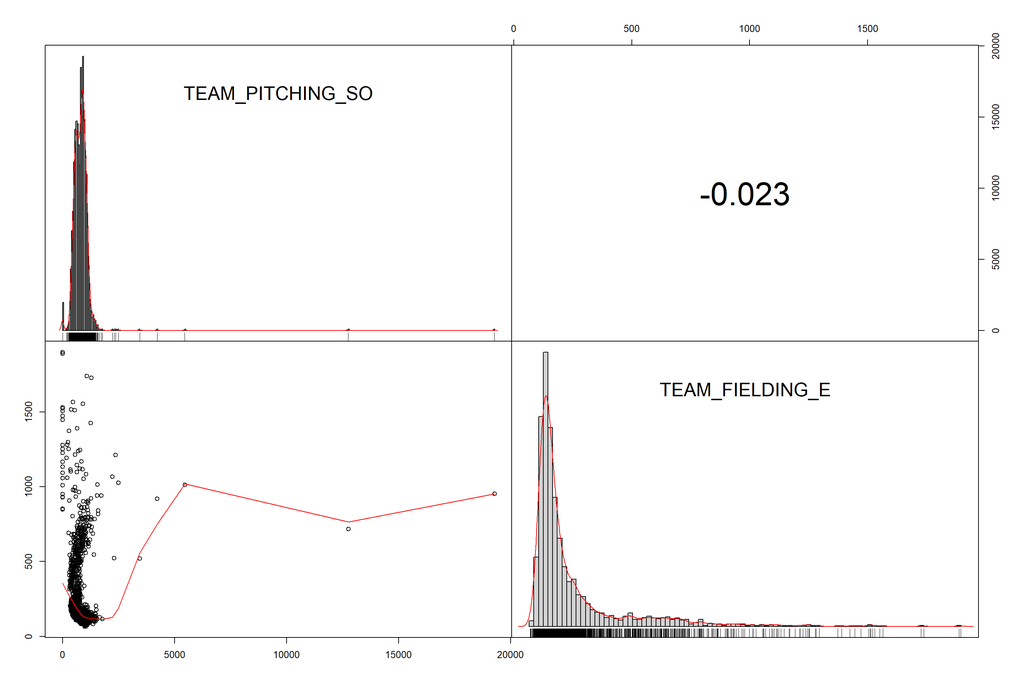

```r
# fielding correlations
chart.Correlation(Fielding_df, histogram=TRUE, pch=19)
```

Let’s also look at the outliers and skewness for each varibale.

### 0.2.3 Outliers and Skewness

```r
par(mfrow=c(3,3))
datasub_1 <- melt(baseball_train)
```

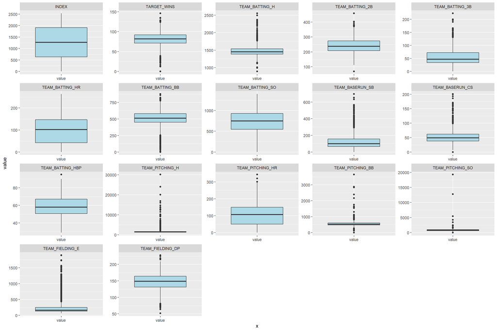

```r
suppressWarnings(ggplot(datasub_1, aes(x= "value", y=value)) +
                   geom_boxplot(fill='lightblue') + facet_wrap(~variable, scales = 'free') )
```

Based on the boxplot we created, TEAM_FIELDING_DP, TEAM_PITCHING_HR, TEAM_BATTING_HR and TEAM_BATTING_SO seem to have the least amount of outliers.

```r
par(mfrow = c(3, 3))
datasub = melt(baseball_train)
```

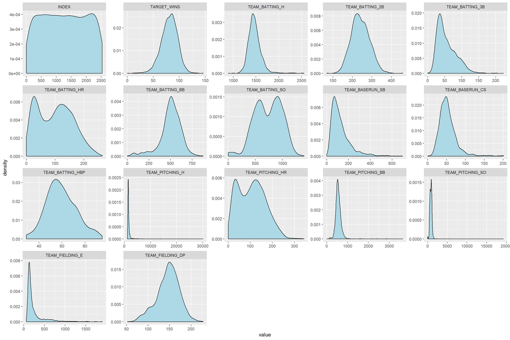

```r
suppressWarnings(ggplot(datasub, aes(x= value)) +
                   geom_density(fill='lightblue') + facet_wrap(~variable, scales = 'free') )
```

```r
metastats %>%
  filter(skew > 1) %>%
  select(STATS, skew) %>%
  arrange(desc(skew))
```

```
##              STATS      skew
## 1 TEAM_PITCHING_SO 22.174554
## 2  TEAM_PITCHING_H 10.329511
## 3 TEAM_PITCHING_BB  6.743899
## 4  TEAM_FIELDING_E  2.990466
## 5  TEAM_BASERUN_CS  1.976218
## 6  TEAM_BASERUN_SB  1.972414
## 7   TEAM_BATTING_H  1.571333
## 8  TEAM_BATTING_3B  1.109465
```

We can see that the most skewed variable is TEAM_PITCHING_SO. We will correct the skewed variables in our data preperation section.

When we are creating a linear regression model, we are looking for the fitting line with the least sum of squares, that has the small residuals with minimized squared residuals. From our correlation analysis, we can see that the explatory variable that has the strongest correlation with TARGET_WINS is TEAM_BATTING_H. Let’s look at a simple model example to further expand our explaroty analysis.

### 0.2.4 Simple Model Example

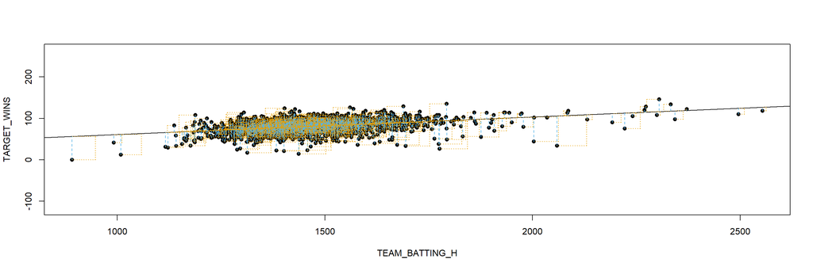

```
##

## Call:
## lm(formula = y ~ x, data = data)
##
## Coefficients:
## (Intercept)            x
##    18.56233      0.04235
##
## Sum of Squares:  479178.4
```

```r
# line that follows the best assocation between two variables

plot_ss(x = TEAM_BATTING_H, y = TARGET_WINS, data=baseball_train, showSquares = TRUE, leastSquares = TRUE)
```

When we are exploring to build a linear regression, one of the first thing we do is to create a scatter plot of the response and explanatory variable.

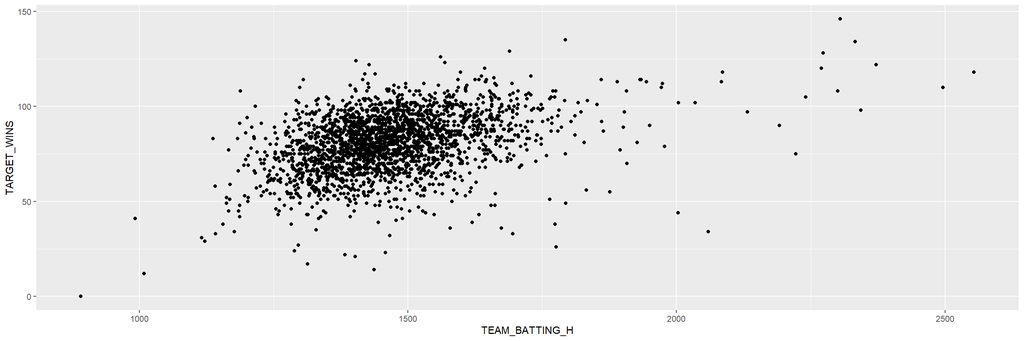

```r
# scatter plot between TEAM_BATTING_H and TARGET_WINS

ggplot(baseball_train, aes(x=TEAM_BATTING_H, y=TARGET_WINS))+
  geom_point()
```

One of the conditions for least square lines or linear regression are Linearity. From the scatter plot between TEAM_BATTING_H and TARGET_WINS, we can see this condition is met. We can also create a scatterplot that shows the data points between TARGET_WINS and each variable.

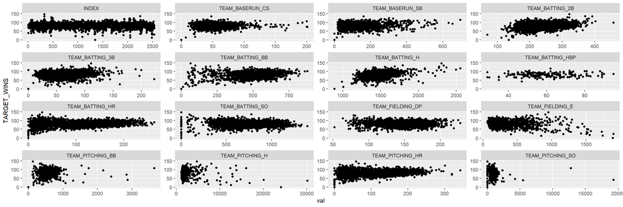

```r
baseball_train %>%
  gather(var, val, -TARGET_WINS) %>%
  ggplot(., aes(val, TARGET_WINS))+
  geom_point()+
  facet_wrap(~var, scales="free", ncol=4)
```

```r
# create a simple example model
lm_sm <- lm(baseball_train$TARGET_WINS ~ baseball_train$TEAM_BATTING_H)
summary(lm_sm)
```

```
##
## Call:
## lm(formula = baseball_train$TARGET_WINS ~ baseball_train$TEAM_BATTING_H)
##
## Residuals:
##     Min      1Q  Median      3Q     Max
## -71.768  -8.757   0.856   9.762  46.016
##
## Coefficients:
##                                Estimate Std. Error t value Pr(>|t|)
## (Intercept)                   18.562326   3.107523   5.973 2.69e-09 ***
## baseball_train$TEAM_BATTING_H  0.042353   0.002105  20.122  < 2e-16 ***
## ---
## Signif. codes:  0 '***' 0.001 '**' 0.01 '*' 0.05 '.' 0.1 ' ' 1
##
## Residual standard error: 14.52 on 2274 degrees of freedom
## Multiple R-squared:  0.1511, Adjusted R-squared:  0.1508
## F-statistic: 404.9 on 1 and 2274 DF,  p-value: < 2.2e-16
```

TARET_BATTING_H has the strongest correlation with TARGET_WINS response variable, however when we create a simple model just using TARGET_BATTING_H, we can only explain 15% of the variablity. (Adjusted R-squared: 0.1508). The remainder of the varibility can be explained with selected other variables within the training dataset.

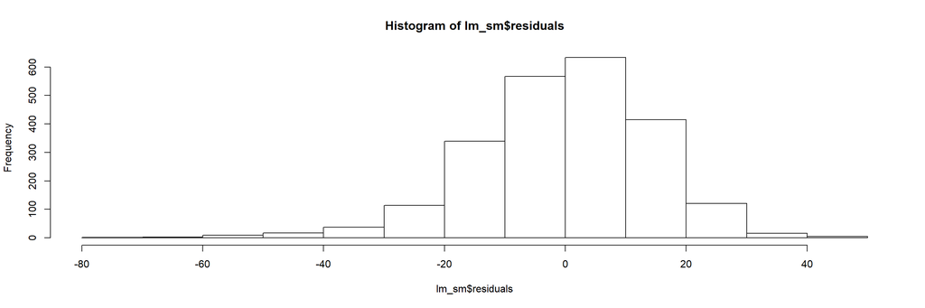

```r
#histogram of residuals for the simple model
hist(lm_sm$residuals)
```

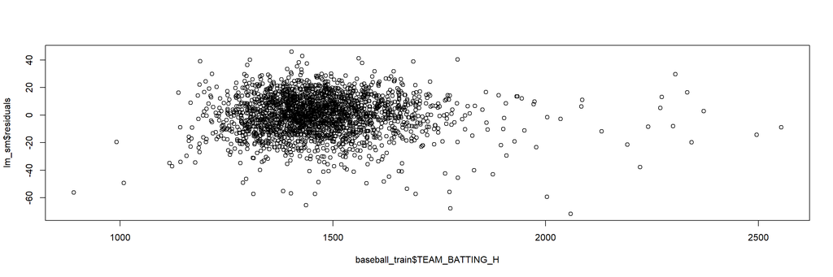

```r
# check for constant variability (honoscedasticity)

plot(lm_sm$residuals ~ baseball_train$TEAM_BATTING_H)
```

We do see that the residuals are distributed normally and variability around the regression line is roughly constant.